# NLP-BASED COST SYNERGY ANALYSIS

The project is the result of numerous post-merger integration failures resulting from **long lead times to synergy realisation**. It is imperative for entities involved in an M&A transaction to quickly identify **overlapping costs** and take rapid action in eliminating those costs. Here, I aim at building a model that can predict the spend category a general cost item belongs to based on the text description of the item itself. Hence, the goal is to **predict common spend categories**, for the items of both the target and the acquirer, in order to gauge the **cost overlaps** for each cost category and act upon the most "synergy-promising".

This will be done by tuning an **NLP algorithm** that uses an expense's **most granular label** (`Commodity Name`) to predict the **three least granular** (most general) labels of the same expense (`Category Name, Subcategory Name, Segment Name`). The model was trained on the **UNSPC dataset**, a dataset that classifies products & items in a standardised way for industrial purposes. After appropriate training, the model will be used on testing data to predict the common cost category for each item in each entity and analyse and prioritise the most significant synergy opportunities.

## Loading packages and data

Before going through the EDA, the Data Preprocessing and the Model Fit, we load all the **functions and packages** we need to perform the first steps. These include `numpy`, `pandas`, `nltk`, `sklearn`, `re` and `matplotlib`.

```python
# Importing all packages needed
import numpy as np
import pandas as pd
import re
import nltk
from nltk.stem import WordNetLemmatizer
from nltk.corpus import wordnet
nltk.download('averaged_perceptron_tagger')
nltk.download('wordnet')
nltk.download('omw-1.4')
import matplotlib.pyplot as plt
from sklearn.feature_extraction.text import TfidfVectorizer
from sklearn.base import BaseEstimator, TransformerMixin
from sklearn.pipeline import Pipeline
from sklearn.multioutput import MultiOutputClassifier
from sklearn.ensemble import RandomForestClassifier
from sklearn.metrics import f1_score
from sklearn.model_selection import KFold
import pickle
```

The **UNSPC** (United Nations Standard Products and Services Code) is a classification system that provides a *standardised* way of *categorising* products and services. For the purpose of the project, we added two higher-level, less granular categories (`Category Name`, `Subcategory Name`) to the four categories given in the original dataset. Here is an overview of the final version of the **training dataset**.

```python
# Loading and visualising the dataset's head
df = pd.read_csv('data-unspsc-codes.csv')
df.head()
```

|  | Category Name | Subcategory Name | Segment | Segment Name | Family | Family Name | Class | Class Name | Commodity | Commodity Name |
| --- | --- | --- | --- | --- | --- | --- | --- | --- | --- | --- |
| 0 | Agricultural and Natural Resources Services an... | Plant and Animal Resources and Products | 10000000 | Live Plant and Animal Material and Accessories... | 10100000 | Live animals | 10101500 | Livestock | 10101501 | Cats |
| 1 | Agricultural and Natural Resources Services an... | Plant and Animal Resources and Products | 10000000 | Live Plant and Animal Material and Accessories... | 10100000 | Live animals | 10101500 | Livestock | 10101502 | Dogs |
| 2 | Agricultural and Natural Resources Services an... | Plant and Animal Resources and Products | 10000000 | Live Plant and Animal Material and Accessories... | 10100000 | Live animals | 10101500 | Livestock | 10101504 | Mink |
| 3 | Agricultural and Natural Resources Services an... | Plant and Animal Resources and Products | 10000000 | Live Plant and Animal Material and Accessories... | 10100000 | Live animals | 10101500 | Livestock | 10101505 | Rats |
| 4 | Agricultural and Natural Resources Services an... | Plant and Animal Resources and Products | 10000000 | Live Plant and Animal Material and Accessories... | 10100000 | Live animals | 10101500 | Livestock | 10101506 | Horses |

```python
# Check NAs
np.sum(df.isnull(), axis=0)
```

```
Category Name       0
Subcategory Name    0
Segment             0
Segment Name        0
Family              0
Family Name         0
Class               0
Class Name          0
Commodity           0
Commodity Name      0
dtype: int64
```

```python
# Number of rows in the dataset
print(f"The DataFrame has {df.shape[0]} rows.")
```

```
The DataFrame has 71502 rows.
```

## Exploratory Data Analysis

We are now going to perform an EDA of the three categories we will train the model on: `Category Name`, `Subcategory Name` and `Segment Name`. This will help us gauge the **distribution** of the different classes within each label and understand how we should handle the classification.

### Category Name

```
There are 12 unique Category Names in the DataFrame.
```

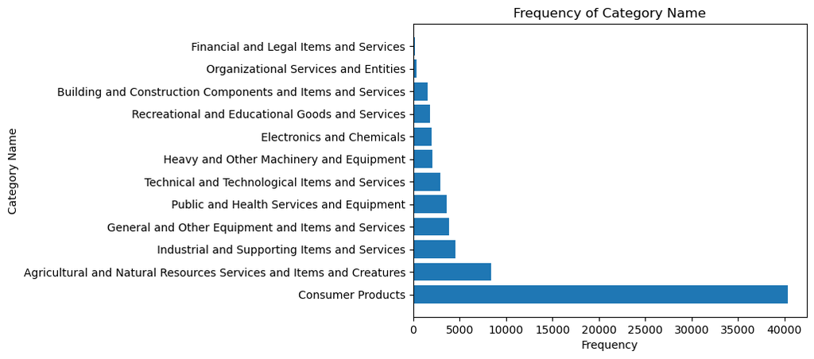

```python
# Check how many Categories
num_category_names = df['Category Name'].nunique()
print(f"There are {num_category_names} unique Category Names in the DataFrame.")

# Create a frequency table of Category Name
freq_table = df['Category Name'].value_counts() #.head(20)

# Plot a horizontal bar chart of the frequency table
plt.barh(freq_table.index, freq_table.values)
plt.title('Frequency of Category Name') # (Top 20)
plt.ylabel('Category Name')
plt.xlabel('Frequency') # customize the plot
plt.show() # display the plot
```

### Subcategory Name

```
There are 29 unique Subcategory Names in the DataFrame.
```

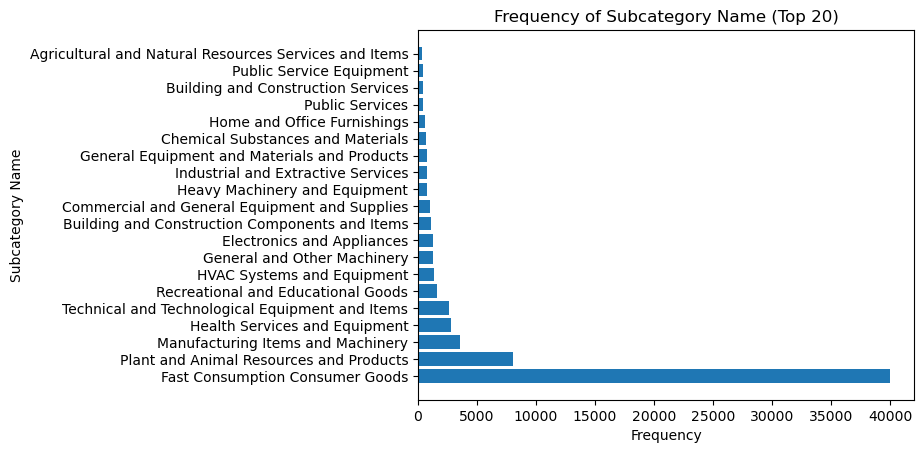

```python
# Check how many Subcategories
num_subcategory_names = df['Subcategory Name'].nunique()
print(f"There are {num_subcategory_names} unique Subcategory Names in the DataFrame.")

# Create a frequency table of Subcategory Name
freq_table = df['Subcategory Name'].value_counts().head(20)

# Plot a horizontal bar chart of the frequency table
plt.barh(freq_table.index, freq_table.values)
plt.title('Frequency of Subcategory Name (Top 20)')
plt.ylabel('Subcategory Name')
plt.xlabel('Frequency') # customize the plot
plt.show() # display the plot
```

### Segment Name

```
There are 57 unique Segment Names in the DataFrame.
```

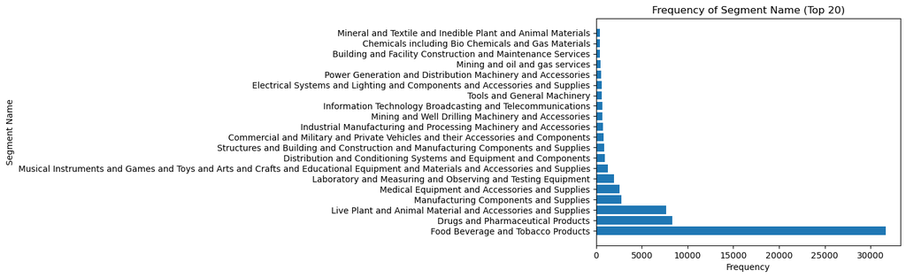

```python
# Check how many Segments
num_segment_names = df['Segment Name'].nunique()
print(f"There are {num_segment_names} unique Segment Names in the DataFrame.")

# Create a frequency table of Segment Name
freq_table = df['Segment Name'].value_counts().head(20)

# Plot a horizontal bar chart of the frequency table
plt.barh(freq_table.index, freq_table.values)
plt.title('Frequency of Segment Name (Top 20)')
plt.ylabel('Segment Name')
plt.xlabel('Frequency') # customize the plot
plt.show() # display the plot
```

As shown for all the three labels, the distribution of the classes is heavily **unbalanced**. Hence, we understand it is crucial to tune the **hyperparameters** of the model picked by trying to maximise the `F1-score` rather than `accuracy`. In fact, `F1-score`, unlike `accuracy`, accounts for unbalanced classes when measuring performance.

## Data Preprocessing

Before passing the input data (the commodity names) through the vectorizer to get it in a format that can be used for prediction, we believed it would be useful to first **lemmatize** the words that appear in the list of commodity names. Lemmatization is the process of **grouping together the different inflected forms of a word** so they can be analyzed as a single item. Lemmatization is similar to stemming but it doesn't reduce some words to the point that they are no longer in the dictionary (which happens in many cases with stemming). Thus, lemmatization links words with similar meanings to one word. Lemmatization is useful for our task because, without it, some words ("egg") and their plural form ("eggs") or other inflected forms of it would be considered as entirely different objects, when in reality they refer to the same thing. Grouping these different forms together should increase the performance of our model.

```python
# Find lexical category of a word to understand its context
def getWordNetPOS(word):
    tag = nltk.pos_tag([word])[0][1][0].upper()
    tagDict = {"J": wordnet.ADJ,
               "N": wordnet.NOUN,
               "V": wordnet.VERB,
               "R": wordnet.ADV}
    return tagDict.get(tag, wordnet.NOUN)

# Lemmatize the word. If string isn't a word in the english dictionary then it's not changed
def lemmatize_word(word):
    return WordNetLemmatizer().lemmatize(word, getWordNetPOS(word))
```

Two examples of lemmatization provided below:

```python
lemmatize_word("accessories")
```

```
'accessory'
```

```python
lemmatize_word("dried")
```

```
'dry'
```

Next, we need to define a customer transformer that can be included as the first step in the pipeline we will build, so that all the words in the list of commodity names are lemmatized before being passed through the TF-IDF vectorizer.

```python
# Defining custom transformer
class CustomTransformer(BaseEstimator, TransformerMixin):
    def __init__(self, your_function):
        self.your_function = your_function

    def fit(self, X, y=None):
        return self

    def transform(self, X):
        return self.your_function(X)


# Defining a function that applies the lemmatization transformation to all input data
def lemmatize_input_strings(word_list):
    word_list = word_list.str.lower().apply(lambda x: re.sub("[^A-Za-z0-9]+", ' ', x)) # Lower-case & drop special-characters apart from hyphen and apostrophe
    word_list = word_list.apply(lambda x: " ".join(list(map(lemmatize_word, x.split(" "))))) # Lemmatize
    return word_list
```

## Tuning the model to maximize F1-score through 5-fold cross validation

**NOTE**: the function `tune_random_forest` deploys a manual hyperparameters tuning. We needed to tune the hyperparameters in order to get the highest **F1-score** on the **lowest** (most granular) predicted level of hierarchy (`Segment Name`). Since the `GridSearchCV` function does not allow to specify the F1-score of a specific variable as a `scoring` parameter, we had to define a kind of *custom logic* to extract that result and choose the combination of hyperparameters according to that result.

```python
# Assign the input data to X and the output data to y
X = df['Commodity Name']
y = df[['Category Name', 'Subcategory Name', 'Segment Name']]
```

```python
# Define a function that will tune random forest over the specified lists of parameters and store the
# results in a dataframe
def tune_random_forest(X, y, tfidf_min_df, tfidf_sublinear_tf, rf_n_estimators, rf_criterion,
                        rf_min_samples_leaf, rf_max_features):

    X_lem=lemmatize_input_strings(X)
    # Generate random indexes that will define the 5 folds used for cross validation
    kf = KFold(n_splits=5, shuffle=True, random_state=1)
    # Create empty lists for f1 scores
    f1_fold_scores_1 = []
    f1_fold_scores_2 = []
    f1_fold_scores_3 = []
    f1_scores_1 = []
    f1_scores_2 = []
    f1_scores_3 = []

    # Create empty lists to store the parameter sets
    a_s = []
    b_s = []
    c_s = []
    d_s = []
    e_s = []
    f_s = []

    i=0

    for a in tfidf_min_df:
        for b in tfidf_sublinear_tf:
            for c in rf_n_estimators:
                for d in rf_criterion:
                    for e in rf_min_samples_leaf:
                        for f in rf_max_features:
                                        # Create the pipeline
                                        pipe_rf = Pipeline([
                                            ('tfidf', TfidfVectorizer(
                                                stop_words="english",
                                                dtype=np.float32,
                                                min_df=a,
                                                sublinear_tf=b)),
                                            ('clf', MultiOutputClassifier(estimator=RandomForestClassifier(
                                                n_estimators=c,
                                                criterion=d,
                                                min_samples_leaf=e,
                                                max_features=f,
                                                random_state=10)))
                                        ])
                                        for j, (train_index, test_index) in enumerate(kf.split(X_lem, y)):
                                            # Fit the pipeline on the training data
                                            pipe_rf.fit(X_lem[train_index], y.loc[train_index, :])
                                            print(i)
                                            i += 1
                                            # Make predictions on the test set
                                            y_pred = pipe_rf.predict(X_lem[test_index])
                                            y_test_vals = y.loc[test_index,:].values

                                            # Calculate and store F1-scores for each fold
                                            f1_1 = f1_score(y_test_vals[:, 0], y_pred[:, 0], average='weighted')
                                            f1_2 = f1_score(y_test_vals[:, 1], y_pred[:, 1], average='weighted')
                                            f1_3 = f1_score(y_test_vals[:, 2], y_pred[:, 2], average='weighted')

                                            f1_fold_scores_1.append(f1_1)
                                            f1_fold_scores_2.append(f1_2)
                                            f1_fold_scores_3.append(f1_3)

                                        # Store mean F1-scores for each set of parameters
                                        f1_scores_1.append(sum(f1_fold_scores_1)/5)
                                        f1_scores_2.append(sum(f1_fold_scores_2)/5)
                                        f1_scores_3.append(sum(f1_fold_scores_3)/5)

                                        f1_fold_scores_1=[]
                                        f1_fold_scores_2=[]
                                        f1_fold_scores_3=[]
                                        a_s.append(a)
                                        b_s.append(b)
                                        c_s.append(c)
                                        d_s.append(d)
                                        e_s.append(e)
                                        f_s.append(f)


    # Create a dictionary for the results
    results_dict = {
        'tfidf_min_dfs': a_s,
        'tfidf_sublinear_tfs': b_s,
        'rf_n_estimators': c_s,
        'rf_criterions': d_s,
        'rf_min_samples_leaf': e_s,
        'rf_max_features': f_s,
        'rf_f1_scores_1': f1_scores_1,
        'rf_f1_scores_2': f1_scores_2,
        'rf_f1_scores_3': f1_scores_3
    }

    # Create a DataFrame from the results dictionary
    results_df = pd.DataFrame(results_dict).sort_values(by=['rf_f1_scores_3'], ascending=False)
    return results_df
```

We will now tune the random forest over the following parameters: tfidf_min_df, tfidf_sublinear_tf, rf_criterion, rf_min_samples_leaf, and rf_max_features. We will keep rf_n_estimators constant at the default value of 100 so that the tuning process doesn't take too long. Moreover, rf_n_estimators cannot be tuned as a higher number of tree estimators will always increase the performance of a random forest ensamble. However, for the final model, which will be trained over the whole dataset, we will use a larger value for the n_estimators parameter (250), and keep the other parameters as the ones that delivered the highest f1-score for the segment category in the tuning process below.

```python
results_df_final = tune_random_forest(X, y, tfidf_min_df=[5, 10, 20], tfidf_sublinear_tf = [True, False], rf_n_estimators=[100],
                    rf_criterion=['gini', 'entropy'], rf_min_samples_leaf=[1,2,4], rf_max_features=[1,2,5,10])
```

```python
# Export dataframe with tuning results
results_df_final.to_csv('results_df_final.csv')
```

```python
# Load and visualise tuning results
results_df_final = pd.read_csv('results_df_final.csv')
results_df_final.head()
```

[output not shown]

```python
# Compute the out of sample performance of the best performing model with n_estimators=250 instead of 100 (final model)
final_model = tune_random_forest(X, y, tfidf_min_df=[results_df_final.loc[0, "tfidf_min_dfs"]],
                                 tfidf_sublinear_tf = [results_df_final.loc[0, "tfidf_sublinear_tfs"]],
                                 rf_n_estimators=[250],
                                 rf_criterion=[results_df_final.loc[0, "rf_criterions"]],
                                 rf_min_samples_leaf=[results_df_final.loc[0, "rf_min_samples_leaf"]],
                                 rf_max_features=[results_df_final.loc[0, "rf_max_features"]])
```

```python
# Export final model results
final_model.to_csv('final_model.csv')
```

```python
# Load and visualise final model results
final_model = pd.read_csv('final_model.csv')
final_model
```

|  | Unnamed: 0 | tfidf_min_dfs | tfidf_sublinear_tfs | rf_n_estimators | rf_criterions | rf_min_samples_leaf | rf_max_features | rf_f1_scores_1 | rf_f1_scores_2 | rf_f1_scores_3 |
| --- | --- | --- | --- | --- | --- | --- | --- | --- | --- | --- |
| 0 | 0 | 5 | False | 250 | gini | 1 | 2 | 0.892957 | 0.881151 | 0.87507 |

## Training the best-performing model over the entire dataset

```python
# Setting up the Pipeline
pipe_rf = Pipeline([
    ('custom_transformer1', CustomTransformer(lemmatize_input_strings)),
    ('tfidf', TfidfVectorizer(
        stop_words="english",
        dtype = np.float32,
        min_df = results_df_final.loc[0, "tfidf_min_dfs"],
        sublinear_tf = results_df_final.loc[0, "tfidf_sublinear_tfs"])),
    ('clf', MultiOutputClassifier(estimator=RandomForestClassifier(
        n_estimators=250,
        criterion=results_df_final.loc[0, "rf_criterions"],
        min_samples_leaf=results_df_final.loc[0, "rf_min_samples_leaf"],
        max_features=results_df_final.loc[0, "rf_max_features"])))
 ])

# Fitting the pipeline
pipe_rf.fit(X, y)
```

## Saving Model Object

```python
# Save the model in working directory
pickle.dump(pipe_rf, open('finalized_model.sav', 'wb'))
```

```python
# Load saved model
loaded_model = pickle.load(open('finalized_model.sav', 'rb'))
```

## Model Sanity Check

### Using the model to make predictions on real client spend data

```python
# Import unlaballed client spend dataset
df_test = pd.read_csv('secondary-spend-analytics-data-set.csv', encoding='latin-1', low_memory=False)

# Drop NAs from column with item descriptions (our model's input)
df_test=df_test.dropna(subset='Short Text')

# Convert Net Value column to float
df_test['Net Value'] = pd.Series(df_test['Net Value'].apply(lambda x: x.replace(",", "")), dtype='float32')

# Model predictions
pd_pred_new=pd.DataFrame(loaded_model.predict(df_test['Short Text']),
                         columns=['Category Name', 'Subcategory Name', 'Segment Name'])

# Check if any NAs in predictions
np.sum(pd_pred_new.isnull(), axis=0)
```

```
Category Name       0
Subcategory Name    0
Segment Name        0
dtype: int64
```

### Visualising frequencies of predictions for different levels of hierarchy

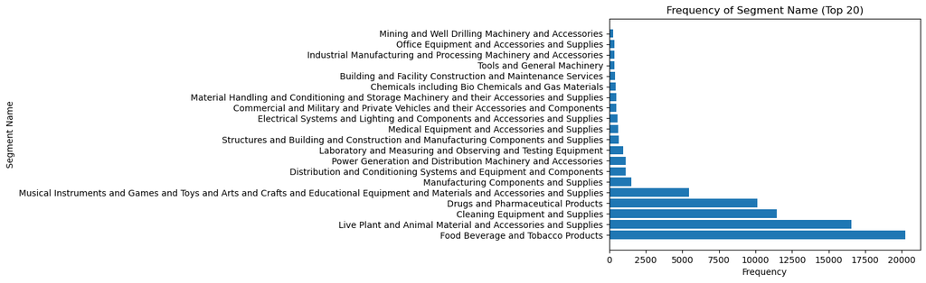

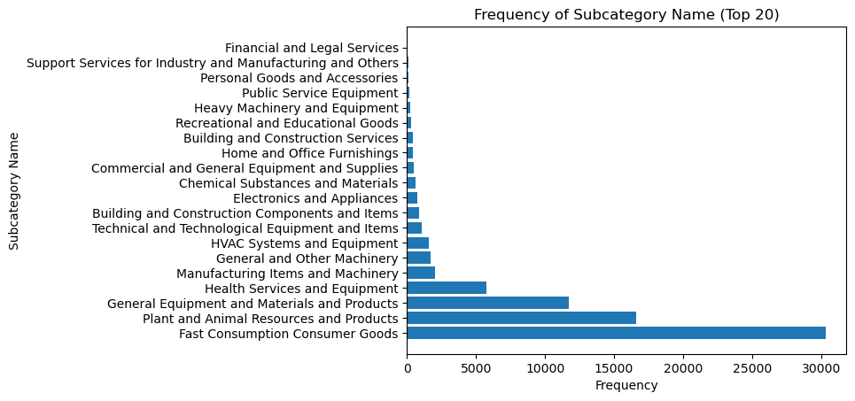

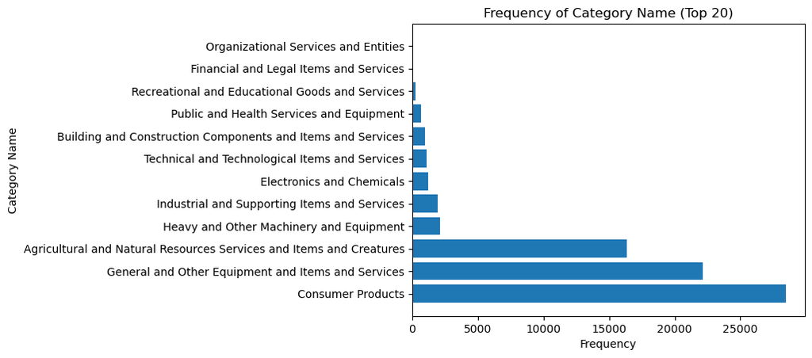

```python
#Segment
freq_table_segment = pd_pred_new['Segment Name'].value_counts().head(20)

plt.barh(freq_table_segment.index, freq_table_segment.values)
plt.title('Frequency of Segment Name (Top 20)')
plt.ylabel('Segment Name')
plt.xlabel('Frequency') # customize the plot
plt.show()


#Subcategory
freq_table_subcategory = pd_pred_new['Subcategory Name'].value_counts().head(20)

plt.barh(freq_table_subcategory.index, freq_table_subcategory.values)
plt.title('Frequency of Subcategory Name (Top 20)')
plt.ylabel('Subcategory Name')
plt.xlabel('Frequency') # customize the plot
plt.show()


#Category
freq_table_category = pd_pred_new['Category Name'].value_counts().head(20)

plt.barh(freq_table_category.index, freq_table_category.values)
plt.title('Frequency of Category Name (Top 20)')
plt.ylabel('Category Name')
plt.xlabel('Frequency') # customize the plot
plt.show()
```

### Relabelling observations without words in the vectorizer as unclassified

Even though the our random forest model will make predictions for obvservations whose item descriptions have no words appearing in the vectorizer matrix, we believe that it is best to label these observations as unclassified rather than relying on the predictions of the model. Therefore, we will attempt to isolate the observations from the client spend data whose descriptions have no words appearing in the pipeline vectorizer and manually label them as unclassifed. We will then analyze the nature of these items and their relative importance within the client's total spend. We'll then proceed to look for any meaningful words within the descriptions of these observations that we might use to manually label these observations and update the training dataset.

```python
# Merge client spend data with the model predictions
df_test = df_test.merge(pd_pred_new, left_index=True, right_index=True)

# Get list of tokens/words in the vectorizer
Word_list= loaded_model.named_steps["tfidf"].get_feature_names_out()

# Find the items from the testing data that don't have words in the vectorizer
count_test_items_not_in_vectorizer=lemmatize_input_strings(df_test["Short Text"]).str.split().apply(
    lambda x: len(set(x).intersection(set(Word_list)))<=0)

# Number of items without words in the vectorizer
sum(count_test_items_not_in_vectorizer)
```

```
8379
```

```python
# Segment predictions for observations that don't have words appearing in the vectorizer
df_test.loc[count_test_items_not_in_vectorizer, 'Segment Name'].value_counts().head(20)
```

```
Drugs and Pharmaceutical Products    8379
Name: Segment Name, dtype: int64
```

```python
# Manually label observations that don't have words appearing in the vectorizer as "Unclassified"
df_test.loc[count_test_items_not_in_vectorizer, "Segment Name"]="Unclassified"
df_test.loc[count_test_items_not_in_vectorizer, "Subcategory Name"]="Unclassified"
df_test.loc[count_test_items_not_in_vectorizer, "Category Name"]="Unclassified"
```

```python
# Export dataframe with classified client spends
df_test.to_csv('df_test.csv')
```

### Visualize frequencies of predictions again

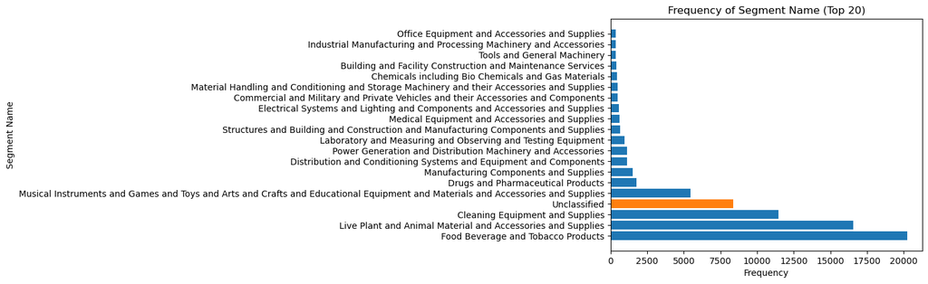

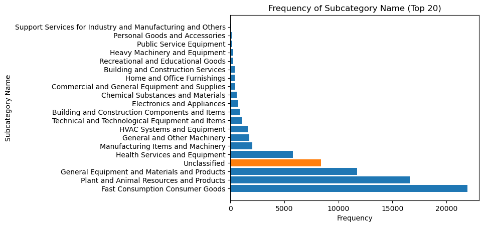

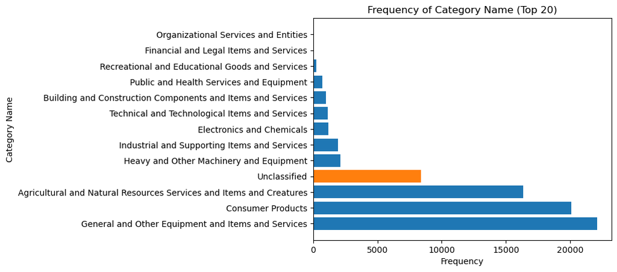

```python
#Segment
freq_table_segment = df_test['Segment Name'].value_counts().head(20)

plt.barh(freq_table_segment.index, freq_table_segment.values)
plt.barh(["Unclassified"], freq_table_segment["Unclassified"])
plt.title('Frequency of Segment Name (Top 20)')
plt.ylabel('Segment Name')
plt.xlabel('Frequency')  # customize the plot
plt.show()


# Subcategory
freq_table_subcategory = df_test['Subcategory Name'].value_counts().head(
    20)


plt.barh(freq_table_subcategory.index, freq_table_subcategory.values)
plt.barh(["Unclassified"], freq_table_subcategory["Unclassified"])
plt.title('Frequency of Subcategory Name (Top 20)')
plt.ylabel('Subcategory Name')
plt.xlabel('Frequency')  # customize the plot
plt.show()


# Category
freq_table_category = df_test['Category Name'].value_counts().head(20)

plt.barh(freq_table_category.index, freq_table_category.values)
plt.barh(["Unclassified"], freq_table_category["Unclassified"])
plt.title('Frequency of Category Name (Top 20)')
plt.ylabel('Category Name')
plt.xlabel('Frequency')  # customize the plot
plt.show()
```

### Calculating the relative importance of unclassified observations in the client's total spend

```python
# Total spend on each unique item that has been labelled as "unclassified"
spending_unclassified = df_test[count_test_items_not_in_vectorizer].groupby(
    by="Short Text")["Net Value"].sum().sort_values(ascending=False).to_frame()
spending_unclassified["Short Text"] = spending_unclassified.index
r = pd.Series(list(range(0, len(spending_unclassified))))
spending_unclassified = spending_unclassified.set_index(r)
spending_unclassified["Percentage of Total Client Spend"] = (spending_unclassified["Net Value"]/
                                                             df_test['Net Value'].sum()).apply('{:.3%}'.format)

spending_unclassified[["Short Text", "Net Value", "Percentage of Total Client Spend"]].head(10)
```

|  | Short Text | Net Value | Percentage of Total Client Spend |
| --- | --- | --- | --- |
| 0 | Maize | 928207808.0 | 3.872% |
| 1 | PL-3 | 838564224.0 | 3.498% |
| 2 | PL-4 | 820847616.0 | 3.424% |
| 3 | PL-5 | 665772928.0 | 2.777% |
| 4 | Khandha | 480527936.0 | 2.004% |
| 5 | C2 | 369001984.0 | 1.539% |
| 6 | C1 | 278983744.0 | 1.164% |
| 7 | PL-6 | 227300016.0 | 0.948% |
| 8 | Maize Gluten | 133224696.0 | 0.556% |
| 9 | Nakki | 126422832.0 | 0.527% |

```python
# Total client spend
df_test['Net Value'].sum()
```

```
23974440000.0
```

```python
# Total unclassfied spend as a percentage of the client's total spend
spending_unclassified["Net Value"].sum()/df_test['Net Value'].sum()
```

```
0.22873165
```

### Extracting possibly classifiable items from the unclassified items with the highest spend

```python
# Define a function which keeps a word if it's in the English dictionary
def is_in_dictionary(x):
    # Load the English dictionary
    with open('english2.txt', 'r') as dictionary_file:
        dictionary = set(word.strip().lower() for word in dictionary_file)
    if x in dictionary and len(x)>3:
        return x
    else:
        return ""

def extract_classifiable_observations(unclassified_obs):
    # Identify words in the English dictionary within the item descriptions of the unclassified observations
    # and join these words together in a new series
    dictionary_words_in_obs = unclassified_obs.str.lower().apply(lambda x: (" ".join(list(map(is_in_dictionary,
                            re.sub("[^A-Za-z0-9]+", ' ', x).split())))).strip()).to_frame(name="Dictionary words")
    # Merge the raw item descriptions and their associated extracted words
    unclassified_obs=unclassified_obs.to_frame().merge(dictionary_words_in_obs, left_index=True, right_index=True)
    # Return only the observations with item descriptions that contained words in the English dictionary and were extracted
    return unclassified_obs[unclassified_obs["Dictionary words"]!=""]

# Take the first 100 unclassified spends from the client data by net value and return only the items with words
# in the english dictionary.
classifiable_observations=extract_classifiable_observations(spending_unclassified.loc[0:99, "Short Text"])
classifiable_observations
```

|  | Short Text | Dictionary words |
| --- | --- | --- |
| 0 | Maize | maize |
| 8 | Maize Gluten | maize gluten |
| 19 | LSP/M-GRIT (Rajsthan) | grit |
| 24 | Bolero SLX | bolero |
| 29 | IB Nefro Killed | killed |
| 34 | MS (Petrol) | petrol |
| 36 | IBH Killed Vacc. | killed |
| 37 | IB Soya DOC (48%) | soya |
| 40 | RCC (M-20) Proportion 1:1.5:3 | proportion |
| 41 | Ashok Leyland 1618 4x2 Tipper - 3607 MM | leyland tipper |
| 42 | Gumboro plus.(2000dose) | plus |
| 44 | Coryza Killed | killed |
| 46 | Inactivated IB+ A Nefro Killed | killed |
| 51 | LSP/M-GRIT | grit |
| 56 | Maruti Swift LDi | swift |
| 58 | PCC (M-7.5) Proportion is 1:4:8 | proportion |
| 59 | Inact. Pullet ND (Chick Neno) | pullet chick |
| 61 | Aqua StrongBond | aqua |
| 62 | Re-organisation of company as below:< | organisation company below |
| 63 | AE Killed | killed |
| 65 | Caustic soda -Kg (Refinary) | caustic soda |
| 66 | ND Inactivated Pullet Killed Vacc. | pullet killed |
| 71 | M1 - Premix | premix |
| 73 | Four wheeler | four wheeler |
| 81 | NEC IP EPABX System SV 9100 | system |
| 84 | Choker | choker |
| 85 | Gelatin | gelatin |
| 91 | ND Killed | killed |
| 92 | Contactor - Mnx12 | contactor |
| 95 | lenovo laptop-V-130 | laptop |

We can now attempt to manually label these observations.

### Importing the dataset with the manually labelled cateogries for the spends above

```python
# Loading and visualising the dataset
new_classified_items = pd.read_excel('classified_items.xlsx')
new_classified_items
```

|  | Short Text | Dictionary Words | Category | Subcategory | Segment | Note |
| --- | --- | --- | --- | --- | --- | --- |
| 0 | Ashok Leyland 1618 4x2 Tipper - 3607 MM | leyland tipper | General and Other Equipment and Items and Serv... | Commercial and General Equipment and Supplies | Commercial and Military and Private Vehicles a... | NaN |
| 1 | Four wheeler | four wheeler | General and Other Equipment and Items and Serv... | Commercial and General Equipment and Supplies | Commercial and Military and Private Vehicles a... | NaN |
| 2 | IB Nefro Killed | killed | Consumer Products | Fast Consumption Consumer Goods | Drugs and Pharmaceutical Products | NaN |
| 3 | IBH Killed Vacc. | killed | Consumer Products | Fast Consumption Consumer Goods | Drugs and Pharmaceutical Products | NaN |
| 4 | Coryza Killed | killed | Consumer Products | Fast Consumption Consumer Goods | Drugs and Pharmaceutical Products | NaN |
| 5 | Inactivated IB+ A Nefro Killed | killed | Consumer Products | Fast Consumption Consumer Goods | Drugs and Pharmaceutical Products | NaN |
| 6 | AE Killed | killed | Consumer Products | Fast Consumption Consumer Goods | Drugs and Pharmaceutical Products | NaN |
| 7 | ND Inactivated Pullet Killed Vacc. | pullet killed | Consumer Products | Fast Consumption Consumer Goods | Drugs and Pharmaceutical Products | NaN |
| 8 | ND Killed | killed | Consumer Products | Fast Consumption Consumer Goods | Drugs and Pharmaceutical Products | NaN |
| 9 | Contactor - Mnx12 | contactor | Electronics and Chemicals | Electronics and Appliances | Electrical Systems and Lighting and Components... | NaN |
| 10 | Maize | maize | Consumer Products | Fast Consumption Consumer Goods | Food Beverage and Tobacco Products | NaN |
| 11 | Maize Gluten | maize gluten | Consumer Products | Fast Consumption Consumer Goods | Food Beverage and Tobacco Products | NaN |
| 12 | Aqua StrongBond | aqua | Consumer Products | Fast Consumption Consumer Goods | Food Beverage and Tobacco Products | NaN |
| 13 | Gelatin | gelatin | Consumer Products | Fast Consumption Consumer Goods | Food Beverage and Tobacco Products | NaN |
| 14 | MS (Petrol) | petrol | Electronics and Chemicals | Chemical Substances and Materials | Fuels and Fuel Additives and Lubricants and An... | NaN |
| 15 | Caustic soda -Kg (Refinary) | caustic soda | Industrial and Supporting Items and Services | Industrial and Extractive Services | Industrial Production and Manufacturing Services | NaN |
| 16 | lenovo laptop-V-130 | laptop | Technical and Technological Items and Services | Technical and Technological Equipment and Items | Information Technology Broadcasting and Teleco... | NaN |
| 17 | LSP/M-GRIT (Rajsthan) | grit | Building and Construction Components and Items... | Building and Construction Components and Items | Land and Buildings and Structures and Thorough... | NaN |
| 18 | LSP/M-GRIT | grit | Building and Construction Components and Items... | Building and Construction Components and Items | Land and Buildings and Structures and Thorough... | NaN |
| 19 | IB Soya DOC (48%) | soya | Agricultural and Natural Resources Services an... | Plant and Animal Resources and Products | Live Plant and Animal Material and Accessories... | NaN |
| 20 | Inact. Pullet ND (Chick Neno) | pullet chick | Agricultural and Natural Resources Services an... | Plant and Animal Resources and Products | Live Plant and Animal Material and Accessories... | NaN |
| 21 | Re-organisation of company as below:< | organisation company below | Organisational Services and Entities | Organisational Services | Management and Business Professionals and Admi... | NaN |
| 22 | Choker | choker | Industrial and Supporting Items and Services | Manufacturing Items and Machinery | Manufacturing Components and Supplies | NaN |
| 23 | Bolero SLX | bolero | NaN | NaN | NaN | NA - Product Model Name |
| 24 | RCC (M-20) Proportion 1:1.5:3 | proportion | NaN | NaN | NaN | Dictionary word too vague |
| 25 | Gumboro plus.(2000dose) | plus | NaN | NaN | NaN | Dictionary word too vague |
| 26 | Maruti Swift LDi | swift | NaN | NaN | NaN | NA - Product Model Name |
| 27 | PCC (M-7.5) Proportion is 1:4:8 | proportion | NaN | NaN | NaN | Dictionary word too vague |
| 28 | M1 - Premix | premix | NaN | NaN | NaN | Dictionary word too vague |
| 29 | NEC IP EPABX System SV 9100 | system | NaN | NaN | NaN | Stopword |